# Getting Started with LegacyNNS: Clustering and Regression

Fred Viole

```r
library(LegacyNNS)
library(data.table)
require(knitr)
require(rgl)
```

# Clustering and Regression

Below are some examples demonstrating unsupervised learning with LegacyNNS clustering and nonlinear regression using the resulting clusters. As always, for a more thorough description and definition, please view the References.

## LegacyNNS Partitioning `LegacyNNS.part()`

**`LegacyNNS.part`** is both a partitional and hierarchical clustering method. `LegacyNNS` iteratively partitions the joint distribution into partial moment quadrants, and then assigns a quadrant identification (1:4) at each partition.

**`LegacyNNS.part`** returns a `data.table` of observations along with their final quadrant identification. It also returns the regression points, which are the quadrant means used in **`LegacyNNS.reg`**.

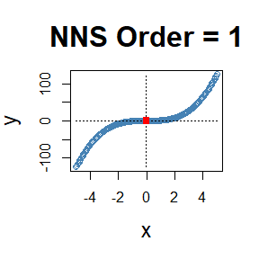

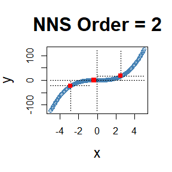

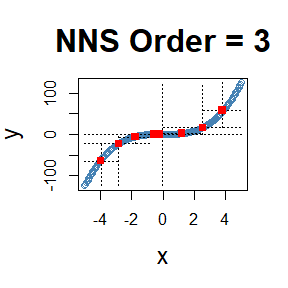

[figure not shown]

```r
x = seq(-5, 5, .05); y = x ^ 3

for(i in 1 : 4){LegacyNNS.part(x, y, order = i, Voronoi = TRUE, obs.req = 0)}
```

### X-only Partitioning

**`LegacyNNS.part`** offers a partitioning based on $x$ values only **`LegacyNNS.part(x, y, type = "XONLY", ...)`**, using the entire bandwidth in its regression point derivation, and shares the same limit condition as partitioning via both $x$ and $y$ values.

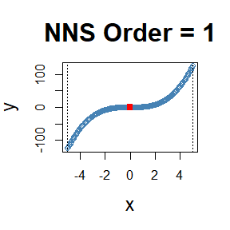

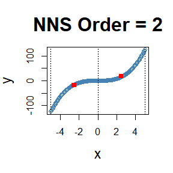

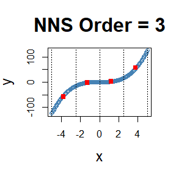

[figure not shown]

```r
for(i in 1 : 4){LegacyNNS.part(x, y, order = i, type = "XONLY", Voronoi = TRUE)}
```

Note the partition identifications are limited to 1’s and 2’s (left and right of the partition respectively), not the 4 values per the $x$ and $y$ partitioning.

```
## $order
## [1] 4
##
## $dt
##          x         y quadrant prior.quadrant
##   1: -5.00 -125.0000    q1111           q111
##   2: -4.95 -121.2874    q1111           q111
##   3: -4.90 -117.6490    q1111           q111
##   4: -4.85 -114.0841    q1111           q111
##   5: -4.80 -110.5920    q1111           q111
##  ---
## 197:  4.80  110.5920    q2222           q222
## 198:  4.85  114.0841    q2222           q222
## 199:  4.90  117.6490    q2222           q222
## 200:  4.95  121.2874    q2222           q222
## 201:  5.00  125.0000    q2222           q222
##
## $regression.points
##    quadrant          x           y
## 1:     q111 -4.4136250 -87.0661563
## 2:     q112 -3.1635313 -32.4322620
## 3:     q121 -1.9133437  -7.4753437
## 4:     q122 -0.6634375  -0.3238252
## 5:     q211  0.5866563   0.2366875
## 6:     q212  1.8366563   6.6437852
## 7:     q221  3.0862812  30.1590941
## 8:     q222  4.3572065  83.8672381
```

## Clusters Used in Regression

The right column of plots shows the corresponding regression (plus endpoints and central point) for the order of `LegacyNNS` partitioning.

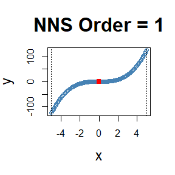

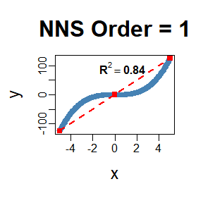

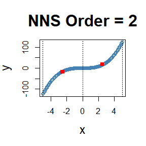

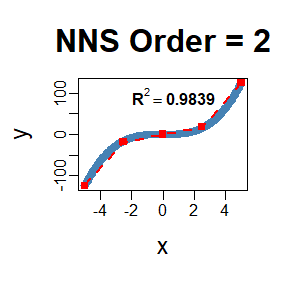

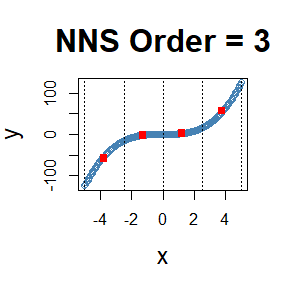

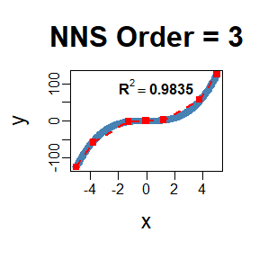

```r
for(i in 1 : 3){LegacyNNS.part(x, y, order = i, obs.req = 0, Voronoi = TRUE, type = "XONLY") ; LegacyNNS.reg(x, y, order = i, ncores = 1)}
```

# LegacyNNS Regression `LegacyNNS.reg()`

**`LegacyNNS.reg`** can fit any $f(x)$, for both uni- and multivariate cases. **`LegacyNNS.reg`** returns a self-evident list of values provided below.

## Univariate:

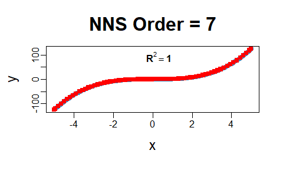

```
## $R2
## [1] 0.9999996
##
## $SE
## [1] 0.04287529
##
## $Prediction.Accuracy
## NULL
##
## $equation
## NULL
##
## $x.star
## NULL
##
```

[output cut: 160 more lines]

```r
LegacyNNS.reg(x, y, ncores = 1)
```

## Multivariate:

Multivariate regressions return a plot of $y$ and $\hat{y}$, as well as the regression points (`$RPM`) and partitions (`$rhs.partitions`) for each regressor.

```r
f = function(x, y) x ^ 3 + 3 * y - y ^ 3 - 3 * x
y = x ; z <- expand.grid(x, y)
g = f(z[ , 1], z[ , 2])
LegacyNNS.reg(z, g, order = "max", plot = FALSE, ncores = 1)
```

```
## $R2
## [1] 1
##
## $rhs.partitions
##         Var1 Var2
##     1: -5.00   -5
##     2: -4.95   -5
##     3: -4.90   -5
##     4: -4.85   -5
##     5: -4.80   -5
##    ---
## 40397:  4.80    5
## 40398:  4.85    5
## 40399:  4.90    5
## 40400:  4.95    5
## 40401:  5.00    5
##
## $RPM
##        Var1  Var2         y.hat
##     1: -4.8 -4.80 -7.105427e-15
##     2: -4.8 -2.55 -8.726063e+01
##     3: -4.8 -2.50 -8.806700e+01
##     4: -4.8 -2.45 -8.883587e+01
##     5: -4.8 -2.40 -8.956800e+01
##    ---
## 40397: -2.6 -2.80  3.776000e+00
## 40398: -2.6 -2.75  2.770875e+00
## 40399: -2.6 -2.70  1.807000e+00
## 40400: -2.6 -2.65  8.836250e-01
## 40401: -2.6 -2.60  1.776357e-15
##
## $Point.est
## NULL
##
## $pred.int
## NULL
##
## $Fitted.xy
##         Var1 Var2          y      y.hat      LegacyNNS.ID residuals
##     1: -5.00   -5   0.000000   0.000000     201.201         0
##     2: -4.95   -5   3.562625   3.562625     402.201         0
##     3: -4.90   -5   7.051000   7.051000     603.201         0
##     4: -4.85   -5  10.465875  10.465875     804.201         0
##     5: -4.80   -5  13.808000  13.808000    1005.201         0
##    ---
## 40397:  4.80    5 -13.808000 -13.808000 39597.40401         0
## 40398:  4.85    5 -10.465875 -10.465875 39798.40401         0
## 40399:  4.90    5  -7.051000  -7.051000 39999.40401         0
## 40400:  4.95    5  -3.562625  -3.562625 40200.40401         0
## 40401:  5.00    5   0.000000   0.000000 40401.40401         0
```

## Inter/Extrapolation

`LegacyNNS.reg` can inter- or extrapolate any point of interest. The **`LegacyNNS.reg(x, y, point.est = ...)`** parameter permits any sized data of similar dimensions to $x$ and called specifically with **`LegacyNNS.reg(...)$Point.est`**.

## LegacyNNS Dimension Reduction Regression

**`LegacyNNS.reg`** also provides a dimension reduction regression by including a parameter **`LegacyNNS.reg(x, y, dim.red.method = "cor", ...)`**. Reducing all regressors to a single dimension using the returned equation **`LegacyNNS.reg(..., dim.red.method = "cor", ...)$equation`**.

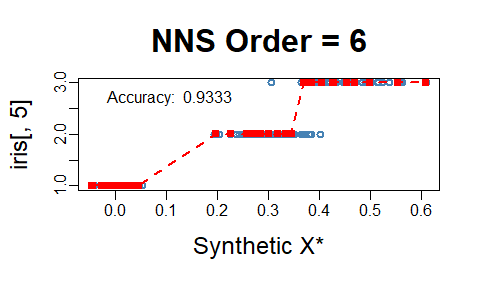

```
##        Variable Coefficient
## 1: Sepal.Length   0.7980781
## 2:  Sepal.Width  -0.4402896
## 3: Petal.Length   0.9354305
## 4:  Petal.Width   0.9381792
## 5:  DENOMINATOR   4.0000000
```

```r
LegacyNNS.reg(iris[ , 1 : 4], iris[ , 5], dim.red.method = "cor", location = "topleft", ncores = 1)$equation
```

Thus, our model for this regression would be:
$$Species = \frac{0.798*Sepal.Length
-0.44*Sepal.Width +0.935*Petal.Length +0.938*Petal.Width}{4}$$

### Threshold

**`LegacyNNS.reg(x, y, dim.red.method = "cor", threshold = ...)`** offers a method of reducing regressors further by controlling the absolute value of required correlation.

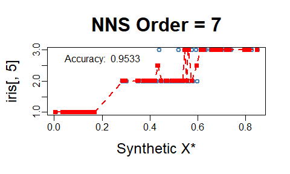

```
##        Variable Coefficient
## 1: Sepal.Length   0.7980781
## 2:  Sepal.Width   0.0000000
## 3: Petal.Length   0.9354305
## 4:  Petal.Width   0.9381792
## 5:  DENOMINATOR   3.0000000
```

```r
LegacyNNS.reg(iris[ , 1 : 4], iris[ , 5], dim.red.method = "cor", threshold = .75, location = "topleft", ncores = 1)$equation
```

Thus, our model for this further reduced dimension regression would be:
$$Species = \frac{\: 0.798*Sepal.Length +
0*Sepal.Width +0.935*Petal.Length +0.938*Petal.Width}{3}$$

and the `point.est = (...)` operates in the same manner as the full regression above, again called with **`LegacyNNS.reg(...)$Point.est`**.

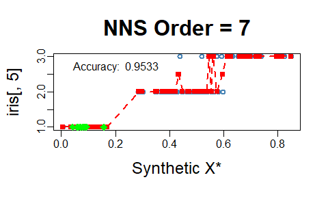

```
##  [1] 1 1 1 1 1 1 1 1 1 1
```

```r
LegacyNNS.reg(iris[ , 1 : 4], iris[ , 5], dim.red.method = "cor", threshold = .75, point.est = iris[1 : 10, 1 : 4], location = "topleft", ncores = 1)$Point.est
```

# Classification

For a classification problem, we simply set **`LegacyNNS.reg(x, y, type = "CLASS", ...)`**.

**NOTE: Base category of response variable should be 1, not 0 for classification problems.**

```r
LegacyNNS.reg(iris[ , 1 : 4], iris[ , 5], type = "CLASS", point.est = iris[1 : 10, 1 : 4], location = "topleft", ncores = 1)$Point.est
```

[figure not shown]

```
##  [1] 1 1 1 1 1 1 1 1 1 1
```

# Cross-Validation `LegacyNNS.stack()`

The **`LegacyNNS.stack`** routine cross-validates for a given objective function the `n.best` parameter in the multivariate **`LegacyNNS.reg`** function as well as the `threshold` parameter in the dimension reduction **`LegacyNNS.reg`** version. **`LegacyNNS.stack`** can be used for classification:

**`LegacyNNS.stack(..., type = "CLASS", ...)`**

or continuous dependent variables:

**`LegacyNNS.stack(..., type = NULL, ...)`**.

Any objective function `obj.fn` can be called using `expression()` with the terms `predicted` and `actual`, even from external packages such as `Metrics`.

**`LegacyNNS.stack(..., obj.fn = expression(Metrics::mape(actual, predicted)), objective = "min")`**.

```r
LegacyNNS.stack(IVs.train = iris[ , 1 : 4],
          DV.train = iris[ , 5],
          IVs.test = iris[1 : 10, 1 : 4],
          dim.red.method = "cor",
          obj.fn = expression( mean(round(predicted) == actual) ),
          objective = "max", type = "CLASS",
          folds = 1, ncores = 1)
```

```r
Folds Remaining = 0
Current LegacyNNS.reg(... , threshold = 0.935 ) MAX Iterations Remaining = 2
Current LegacyNNS.reg(... , threshold = 0.795 ) MAX Iterations Remaining = 1
Current LegacyNNS.reg(... , threshold = 0.44 ) MAX Iterations Remaining = 0
Current LegacyNNS.reg(... , n.best = 1 ) MAX Iterations Remaining = 12
Current LegacyNNS.reg(... , n.best = 2 ) MAX Iterations Remaining = 11
Current LegacyNNS.reg(... , n.best = 3 ) MAX Iterations Remaining = 10
Current LegacyNNS.reg(... , n.best = 4 ) MAX Iterations Remaining = 9
$OBJfn.reg
[1] 1

$LegacyNNS.reg.n.best
[1] 4

$probability.threshold
[1] 0.43875

$OBJfn.dim.red
[1] 0.9666667

$LegacyNNS.dim.red.threshold
[1] 0.935

$reg
 [1] 1 1 1 1 1 1 1 1 1 1

$reg.pred.int
NULL

$dim.red
 [1] 1 1 1 1 1 1 1 1 1 1

$dim.red.pred.int
NULL

$stack
 [1] 1 1 1 1 1 1 1 1 1 1

$pred.int
NULL
```

## Increasing Dimensions

Given multicollinearity is not an issue for nonparametric regressions as it is for OLS, in the case of an ill-fit univariate model a better option may be to increase the dimensionality of regressors with a copy of itself and cross-validate the number of clusters `n.best` via:

**`LegacyNNS.stack(IVs.train = cbind(x, x), DV.train = y, method = 1, ...)`**.

```r
set.seed(123)
x = rnorm(100); y = rnorm(100)

LegacyNNS.params = LegacyNNS.stack(IVs.train = cbind(x, x),
                        DV.train = y,
                        method = 1, ncores = 1)
```

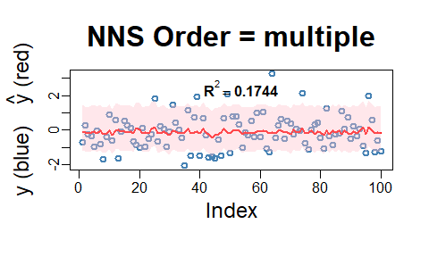

```r
LegacyNNS.reg(cbind(x, x), y,
        n.best = LegacyNNS.params$LegacyNNS.reg.n.best,
        point.est = cbind(x, x),
        residual.plot = TRUE,
        ncores = 1, confidence.interval = .95)
```

# References

If the user is so motivated, detailed arguments further examples are provided within the following:

- [Nonlinear Nonparametric Statistics: Using Partial Moments](https://github.com/OVVO-Financial/LegacyNNS/blob/LegacyNNS-Beta-Version/examples/index.md)
- [Deriving Nonlinear Correlation Coefficients from Partial Moments](https://doi.org/10.2139/ssrn.2148522)
- [Nonparametric Regression Using Clusters](https://doi.org/10.1007/s10614-017-9713-5)
- [Clustering and Curve Fitting by Line Segments](https://doi.org/10.2139/ssrn.2861339)
- [Classification Using LegacyNNS Clustering Analysis](https://doi.org/10.2139/ssrn.2864711)
- [Partitional Estimation Using Partial Moments](https://doi.org/10.2139/ssrn.3592491)